# Data Visualization

Ali Paulson

February 14, 2019

The data we are using is from Alaska Department of Fish and Game, Division of Commercial Fisheries. 2017. Daily salmon escapement counts from the OceanAK database, Alaska, 1921-2017. Knowledge Network for Biocomplexity. doi:10.5063/F1S46Q6M.

# Reformat the data for plotting

```r
salmon <- read.csv(url("https://knb.ecoinformatics.org/knb/d1/mn/v2/object/urn%3Auuid%3Af119a05b-bbe7-4aea-93c6-85434dcb1c5e", method = "libcurl"), stringsAsFactors = F)

head(salmon)
```

```
##        Location SASAP.Region sampleDate Species DailyCount  Method
## 1 Akalura Creek       Kodiak 1930-05-24 Sockeye          4 Unknown
## 2 Akalura Creek       Kodiak 1930-05-25 Sockeye         10 Unknown
## 3 Akalura Creek       Kodiak 1930-05-26 Sockeye          0 Unknown
## 4 Akalura Creek       Kodiak 1930-05-27 Sockeye          0 Unknown
## 5 Akalura Creek       Kodiak 1930-05-28 Sockeye          0 Unknown
## 6 Akalura Creek       Kodiak 1930-05-29 Sockeye          0 Unknown
##   Latitude Longitude Source
## 1  57.1641 -154.2287   ADFG
## 2  57.1641 -154.2287   ADFG
## 3  57.1641 -154.2287   ADFG
## 4  57.1641 -154.2287   ADFG
## 5  57.1641 -154.2287   ADFG
## 6  57.1641 -154.2287   ADFG
```

- Calculate annual escapment by species and regoin
  - `separate`
  - `group_by`
  - `summarize` using `sum` function
- filter for just Pacific salmon species (Sockeye, Chinook, Coho, Pink, Chum)

```r
annual_esc <- salmon %>%
  separate(sampleDate, into = c("year", "month", "day"), sep = "-") %>%
  group_by(year, SASAP.Region, Species) %>%
  summarize(escapement = sum(DailyCount)) %>%
  filter(Species %in% c("Sockeye", "Chinook", "Coho", "Pink", "Chum")) %>%
  ungroup() %>%
  #coerce year to numeric type:
  mutate(year = as.numeric(year))

head(annual_esc)
```

```
## # A tibble: 6 x 4
##    year SASAP.Region Species escapement
##   <dbl> <chr>        <chr>        <int>
## 1  1921 Kodiak       Sockeye    1325061
## 2  1922 Chignik      Chinook        242
## 3  1922 Chignik      Sockeye     428977
## 4  1922 Kodiak       Sockeye     384683
## 5  1923 Chignik      Chinook        286
## 6  1923 Chignik      Sockeye     216124
```

# Generate some static plots

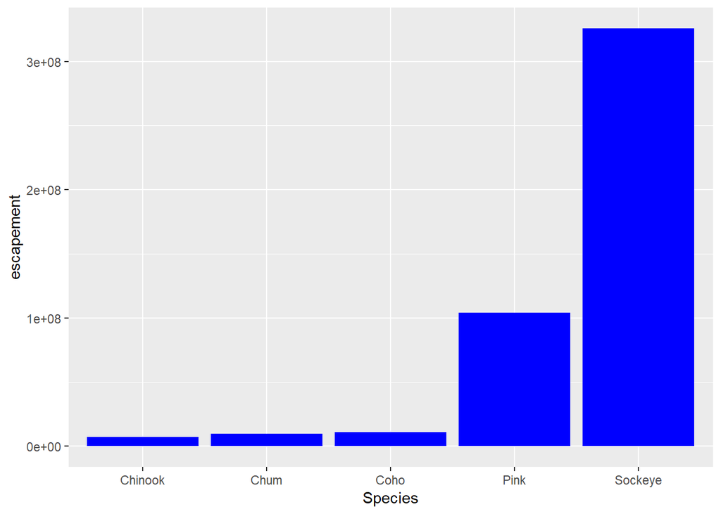

```r
#Better practice to put your mapping in the ggplot call rather than the geom call, unless you are trying to map different parameters on the same plot

ggplot(annual_esc, mapping = aes(x = Species, y = escapement))+
  geom_col(fill = "blue")
```

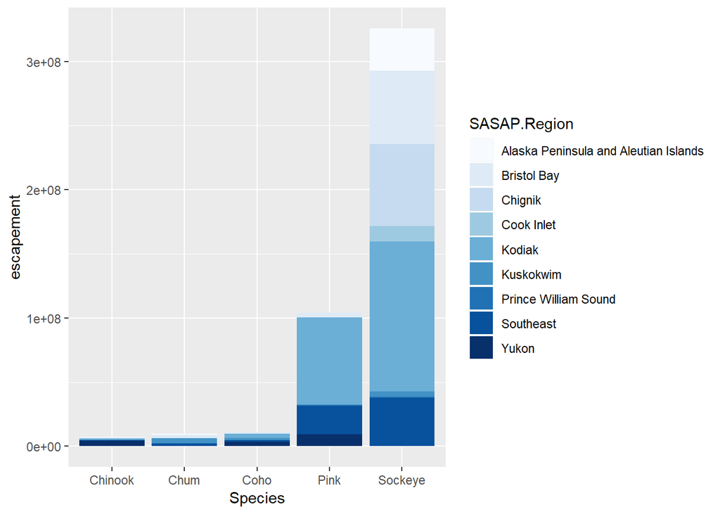

```r
#Check out other color palettes with RColorBrewer

#What if you do want to map something with the fill aesthetic?
ggplot(annual_esc, mapping = aes(x = Species, y = escapement, fill = SASAP.Region))+
  scale_fill_brewer(palette = 1)+ #Can choose different palettes for the fill
  geom_col()
```

What if we just wanted to plot the Kodiak escapement?

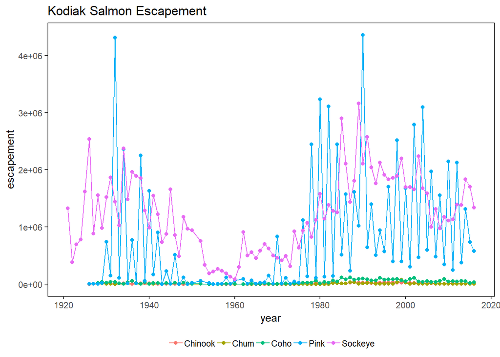

```r
annual_esc %>%
  filter(SASAP.Region == "Kodiak") %>%
  ggplot(aes(x = year, y = escapement, color = Species))+
  geom_line()+
  geom_point()+
  ggtitle("Kodiak Salmon Escapement")+
  theme_test() + #Can use different ggplot themes to make things prettier
  theme(legend.position = "bottom", legend.title = element_blank())
```

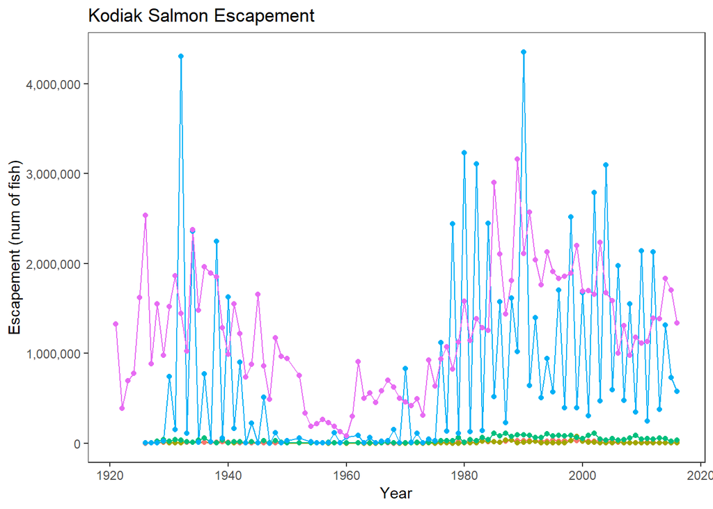

```r
#These theme calls for ggplot can get really long, but you can save your theme function calls to an object:

my_theme = theme_test()+
  theme(legend.position = "Bottom", legend.title = element_blank())

#This makes your code more dry, less repetition, easier to read.
#You want to avoid calling theme twice though - as you can easily overwrite some of the things that you set as your theme - so if you have a theme() in your my_theme, you might overwrite things - just be careful.
#Use scale package to fix up the axis labels

annual_esc %>%
  filter(SASAP.Region == "Kodiak") %>%
  ggplot(aes(x = year, y = escapement, color = Species))+
  geom_line()+
  geom_point()+
  scale_y_continuous(labels = comma)+
  ggtitle("Kodiak Salmon Escapement")+
  xlab("Year") +
  ylab("Escapement (num of fish)") +
  my_theme #Add in the mytheme object!
```

Let’s make multiple plots, one for each region.

[figure not shown]

```r
p <- ggplot(annual_esc, aes(x = year, y = escapement, color = Species))+
  geom_line()+
  geom_point()+
  scale_y_continuous(labels = comma)+
  facet_wrap(~SASAP.Region, scales = "free_y", ncol =2)+
  ggtitle("Kodiak Salmon Escapement")+
  xlab("Year") +
  ylab("Escapement (num of fish)") +
  my_theme #Add in the mytheme object!

p
```

```r
ggsave("figures/regional_escapement.png",
       plot = p, width = 7, height = 8, units = "in")
```

Can also turn some parts of R chunks on or off

# Generate an interactive map using leaflet

Map the sampling locations for escapement. Starting back with the unsummarized data.

- Find distinct lat/long/location combinations, using the `distinct`
- the `drop_na` function removes whole rows that contain an NA anywhere - could be dangerous, so be careful it’s doing what you think.

```
##         Location Latitude Longitude
## 1  Akalura Creek  57.1641 -154.2287
## 4    Anvik River  62.7000 -160.2000
## 6 Ayakulik River  57.1956 -154.5290
## 7     Bear Creek  56.0389 -160.2734
## 8     Bear River  56.0389 -160.2734
## 9  Big Bay Creek  58.5426 -152.5683
```

|  | Location | Latitude | Longitude |
| --- | --- | --- | --- |
| 1 | Akalura Creek | 57.1641 | -154.2287 |
| 4 | Anvik River | 62.7 | -160.2 |
| 6 | Ayakulik River | 57.1956 | -154.529 |
| 7 | Bear Creek | 56.0389 | -160.2734 |
| 8 | Bear River | 56.0389 | -160.2734 |
| 9 | Big Bay Creek | 58.5426 | -152.5683 |
| 10 | Big Kitoi Creek | 58.1915 | -152.3754 |
| 12 | Black Lake | 56.392 | -158.937 |
| 13 | Buskin River | 57.7768 | -152.5372 |
| 14 | Chelatna Lake | 62.4731 | -151.4545 |

[output cut: 58 more lines]

Let’s make a map!

- use pipes with the leaflet package, rather than plus signs
- Leaflet has a ton of functionality - can create an html block within the popups, can put in plots/hyperlinks into the popups
- This isn’t greaet for developing static maps - a new package called sf - this integrates with ggplot2 for mapping vector files.
- Can create custom markers in leaflet as well.

```r
leaflet(locations) %>%
  addTiles() %>% #Can change projection, but will have to use different tiles - default tiles use mercator
  addMarkers(lng = ~Longitude, lat = ~Latitude, popup = ~Location)
```

[interactive chart not shown]